# Final_Project_Report(1)

## **Voice-Driven mood detection and personalized entertainment recommendation**

**Group members:**

**Runlu Dong(1011563675)**

**Ziyu Lyu(1006899395)**

**Mengyang Liu(1006702739)**

In this project, we aim to develop a **Voice-Driven Mood Detection and Personalized Entertainment Recommendation System**. The system will analyze human emotions from voice recordings and suggest personalized entertainment content based on the detected mood. By leveraging deep learning techniques in speech and utterances analysis, we will build a model capable of accurately classifying emotions and connecting to an API to generate entertainment recommendations.

### **Dataset**

To train and evaluate our model, we will use the **Emotional Speech Data dataset**, sourced from: https://github.com/HLTSingapore/Emotional-Speech-Data.

This dataset contains various emotional speech recordings, which will be essential for training our deep learning model to recognize different emotional tones in voice inputs. The dataset provides 5 labeled emotional categories, which are Neutral, Happy, Sad, Angry and Surprise.

**Citation:**

Kun Zhou, Berrak Sisman, Rui Liu, Haizhou Li, Emotional voice conversion: Theory, databases and ESD, Speech Communication, Volume 137, 2022, Pages 1-18, ISSN 0167-6393, https://doi.org/10.1016/j.specom.2021.11.006. (https://www.sciencedirect.com/science/article/pii/S0167639321001308)

Link to dataset: https://drive.google.com/drive/folders/1bI8y5yTt6wFyRC14RvQ9c0EISWMXeYyU

```python
import torch
from torch.utils.data import TensorDataset
from transformers import Wav2Vec2FeatureExtractor, Wav2Vec2Model
from torchvision import datasets, transforms
from torch.utils.data import DataLoader, random_split, TensorDataset
import torch
import torch.nn as nn
import torch.nn.functional as F
import numpy as np
import torch.optim as optim
import time
```

```python
from google.colab import drive
drive.mount('/content/drive')
```

```python
!ls "/content/drive/MyDrive/MIE1517 project"
```

```
 API_1517_1.ipynb
 API_1517.ipynb
 app.ipynb
 best_model_CNN_bs32_lr0.0005_epoch12_acc0.9248.pth
 best_model_CNN_bs32_lr0.0005_epoch9_acc0.9238.pth
 best_model_CNN_bs32_lr0.001_epoch14_acc0.9244.pth
 best_model_CNN_bs64_lr0.001_epoch15_acc0.9234.pth
 Dataset_Link.gdoc
'Emotional Speech Dataset (ESD)'
'Emotional Speech Dataset (ESD).zip'
 final_proj_progress.ipynb
 frank_test_script
 group13_1517project.ipynb
'hugging face web'
'MIE1517 final project presentation.gslides'
 MIE1517_F.ipynb
'Request for Team Formation and Project Approval - Group 13.gdoc'
'Test of group13_1517project.ipynb'
```

```python
import zipfile
import os

# Define the dataset path
zip_path = "/content/drive/MyDrive/MIE1517 project/Emotional Speech Dataset (ESD).zip"
extract_path = "/content/drive/MyDrive/MIE1517 project/Emotional Speech Dataset (ESD)"

# Unzip the dataset
#with zipfile.ZipFile(zip_path, 'r') as zip_ref:
    #zip_ref.extractall(extract_path)

print("Dataset extracted successfully!")
```

```
Dataset extracted successfully!
```

**The ESD dataset contains 350 parallel utterances spoken by 10 native English and 10 native Chinese speakers, covering 5 emotion categories(neutral, happy, angry, sad and surprise).**

**Here is the summary of dataset.**

```python
import os
import pandas as pd

dataset_path = "/content/drive/MyDrive/MIE1517 project/Emotional Speech Dataset (ESD)/Emotion Speech Dataset"

mood_categories = ["Angry", "Happy", "Neutral", "Sad", "Surprise"]
speaker_ids = [f"{i:04d}" for i in range(1, 21)]  # Generates '0001' to '0020'

#Initialize counters
total_files = 0
mood_counts = {mood: 0 for mood in mood_categories}

#Traverse dataset using known structure
for speaker in speaker_ids:
    speaker_path = os.path.join(dataset_path, speaker)

    if os.path.isdir(speaker_path):
        for mood in mood_categories:
            mood_path = os.path.join(speaker_path, mood)

            if os.path.isdir(mood_path):
                num_files = len([f for f in os.listdir(mood_path) if f.endswith(".wav")])
                mood_counts[mood] += num_files
                total_files += num_files

mood_counts_df = pd.DataFrame(list(mood_counts.items()), columns=["Mood", "File Count"])

#Print summary
print(f"Total Audio Files: {total_files}")
print(f"Total Unique Speakers: {len(speaker_ids)}")
print(f"Total Mood Categories: {len(mood_categories)}")
```

```
Total Audio Files: 35000
Total Unique Speakers: 20
Total Mood Categories: 5
```

```python
mood_counts_df
```

|  | Mood | File Count |
| --- | --- | --- |
| 0 | Angry | 7000 |
| 1 | Happy | 7000 |
| 2 | Neutral | 7000 |
| 3 | Sad | 7000 |
| 4 | Surprise | 7000 |

**We have chosen the facebook/wav2vec2-base model for our project due to its strong capability in learning speech representations from raw audio waveforms without requiring extensive labeled data. Unlike models specifically fine-tuned for emotion recognition, this model retains general speech features, allowing us to fine-tune it on our dataset for mood classification. Additionally, wav2vec2-base is computationally efficient compared to larger variants, making it feasible for training with limited resources. Since our system aims to detect emotions from voice input and provide personalized recommendations, leveraging this model ensures that we extract meaningful speech features while maintaining adaptability for emotion classification tasks.**

### **Data Processing**

```python
from transformers import Wav2Vec2Model
device = torch.device("cuda" if torch.cuda.is_available() else "cpu")

model_name = "facebook/wav2vec2-base"
feature_extractor = Wav2Vec2FeatureExtractor.from_pretrained(model_name)
model = Wav2Vec2Model.from_pretrained(model_name)
model.to(device)
```

```
Wav2Vec2Model(
  (feature_extractor): Wav2Vec2FeatureEncoder(
    (conv_layers): ModuleList(
      (0): Wav2Vec2GroupNormConvLayer(
        (conv): Conv1d(1, 512, kernel_size=(10,), stride=(5,), bias=False)
        (activation): GELUActivation()
        (layer_norm): GroupNorm(512, 512, eps=1e-05, affine=True)
      )
      (1-4): 4 x Wav2Vec2NoLayerNormConvLayer(
        (conv): Conv1d(512, 512, kernel_size=(3,), stride=(2,), bias=False)
        (activation): GELUActivation()
      )
      (5-6): 2 x Wav2Vec2NoLayerNormConvLayer(
        (conv): Conv1d(512, 512, kernel_size=(2,), stride=(2,), bias=False)
        (activation): GELUActivation()
      )
    )
  )
  (feature_projection): Wav2Vec2FeatureProjection(
    (layer_norm): LayerNorm((512,), eps=1e-05, elementwise_affine=True)
    (projection): Linear(in_features=512, out_features=768, bias=True)
    (dropout): Dropout(p=0.1, inplace=False)
  )
  (encoder): Wav2Vec2Encoder(
    (pos_conv_embed): Wav2Vec2PositionalConvEmbedding(
      (conv): ParametrizedConv1d(
        768, 768, kernel_size=(128,), stride=(1,), padding=(64,), groups=16
        (parametrizations): ModuleDict(
          (weight): ParametrizationList(
            (0): _WeightNorm()
          )
        )
      )
      (padding): Wav2Vec2SamePadLayer()
      (activation): GELUActivation()
    )
    (layer_norm): LayerNorm((768,), eps=1e-05, elementwise_affine=True)
    (dropout): Dropout(p=0.1, inplace=False)
    (layers): ModuleList(
      (0-11): 12 x Wav2Vec2EncoderLayer(
        (attention): Wav2Vec2SdpaAttention(
          (k_proj): Linear(in_features=768, out_features=768, bias=True)
          (v_proj): Linear(in_features=768, out_features=768, bias=True)
          (q_proj): Linear(in_features=768, out_features=768, bias=True)
          (out_proj): Linear(in_features=768, out_features=768, bias=True)
        )
        (dropout): Dropout(p=0.1, inplace=False)
        (layer_norm): LayerNorm((768,), eps=1e-05, elementwise_affine=True)
        (feed_forward): Wav2Vec2FeedForward(
          (intermediate_dropout): Dropout(p=0.0, inplace=False)
          (intermediate_dense): Linear(in_features=768, out_features=3072, bias=True)
          (intermediate_act_fn): GELUActivation()
          (output_dense): Linear(in_features=3072, out_features=768, bias=True)
          (output_dropout): Dropout(p=0.1, inplace=False)
        )
        (final_layer_norm): LayerNorm((768,), eps=1e-05, elementwise_affine=True)
      )
    )
  )
)
```

```python
import os
import torch
import librosa
from torch.utils.data import Dataset

class ESDDataset(Dataset):
    def __init__(self, data_path, feature_extractor, max_duration=5):
        self.data_path = data_path
        self.feature_extractor = feature_extractor
        self.audio_files = []
        self.labels = []
        self.max_duration = max_duration

        #Set emotion categories
        self.emotion_dict = {"Neutral": 0, "Happy": 1, "Angry": 2, "Sad": 3, "Surprise": 4}

        for speaker in os.listdir(data_path):
            speaker_path = os.path.join(data_path, speaker)
            if not os.path.isdir(speaker_path):
                continue

            for emotion, label in self.emotion_dict.items():
                emotion_folder = os.path.join(speaker_path, emotion)
                if not os.path.exists(emotion_folder):
                    continue

                for file in os.listdir(emotion_folder):
                    if file.endswith(".wav"):
                        file_path = os.path.join(emotion_folder, file)
                        self.audio_files.append(file_path)
                        self.labels.append(label)

        print(f"Find {len(self.audio_files)} audio samples.")

    def __len__(self):
        return len(self.audio_files)

    def __getitem__(self, idx):
        audio_path = self.audio_files[idx]
        label = self.labels[idx]

        #Load audio
        audio, sr = librosa.load(audio_path, sr=16000)

        #Limit the maximum duration
        max_samples = int(self.max_duration * sr)
        if len(audio) > max_samples:
            audio = audio[:max_samples]

        #Dealing the audio to the format that is suitable for Wav2Vec2 use
        inputs = self.feature_extractor(audio, sampling_rate=sr, return_tensors="pt", padding=True)

        return {
            "input_values": inputs["input_values"].squeeze(0),
            "labels": torch.tensor(label)
        }
```

**To evaluate the feasibility and effectiveness of our Voice-Driven Mood Detection Model, we will begin with a preliminary experiment using a subset of the dataset. Instead of utilizing all available data, we will select three speakers for initial training and validation. This will allow us to quickly assess whether the model can learn meaningful patterns from the speech recordings and accurately classify emotions.**

```python
data_path = "/content/drive/MyDrive/MIE1517 project/Emotional Speech Dataset (ESD)/3groupEng"

#Using 3 people as our initial training
dataset = ESDDataset(data_path, feature_extractor)

print(f"Length of dataset: {len(dataset)}")
```

```
Find 5250 audio samples.
Length of dataset: 5250
```

```python
from torchvision import datasets, transforms
from torch.utils.data import DataLoader, random_split, TensorDataset
import torch
import torch.nn as nn
import torch.nn.functional as F
```

To prepare our dataset for training, validation, and testing, we define a collation function to handle variable length audio sequences. Since speech recordings differ in duration, padding is applied to ensure uniform batch sizes, making processing more efficient. The dataset is then split into 70% training, 15% validation, and 15% testing to facilitate effective model training and evaluation.

We use DataLoaders to streamline batch processing, ensuring that training batches are shuffled for better generalization, while validation and test batches remain ordered for stable evaluation.

Batch inspection is performed to verify that the input values and labels are correctly formatted before training.

```python
def collate_fn(batch):
    input_values = [item["input_values"] for item in batch]
    labels = torch.tensor([item["labels"] for item in batch], dtype=torch.long)

    # Align the audio lengths in the batch (Pads sequences)
    input_values = torch.nn.utils.rnn.pad_sequence(input_values, batch_first=True, padding_value=0)

    return {"input_values": input_values, "labels": labels}
```

```python
#Set the data set path
data_path = "/content/drive/MyDrive/MIE1517 project/Emotional Speech Dataset (ESD)/3groupEng"
dataset = ESDDataset(data_path, feature_extractor)

#Divide the data set (70% training, 15% validation, 15% testing)
train_size = int(0.7 * len(dataset))
val_size = int(0.15 * len(dataset))
test_size = len(dataset) - train_size - val_size

train_dataset, val_dataset, test_dataset = random_split(dataset, [train_size, val_size, test_size])

#Set DataLoader
train_loader = DataLoader(train_dataset, batch_size=1, shuffle=True, collate_fn=collate_fn)
val_loader = DataLoader(val_dataset, batch_size=1, shuffle=False, collate_fn=collate_fn)
test_loader = DataLoader(test_dataset, batch_size=1, shuffle=False, collate_fn=collate_fn)

print(f"Training set size: {len(train_dataset)}")
print(f"Validation set size: {len(val_dataset)}")
print(f"Testing set size: {len(test_dataset)}")
```

```
Find 5250 audio samples.
Training set size: 3674
Validation set size: 787
Testing set size: 789
```

```python
batch = next(iter(train_loader))

print(f"Batch input_values shape: {batch['input_values'].shape}")  # (batch_size, max_seq_length)
print(f"Batch labels shape: {batch['labels'].shape}")  # (batch_size,)
print(f"Batch input_values dtype: {batch['input_values'].dtype}")  # torch.float32
print(f"Batch labels dtype: {batch['labels'].dtype}")  # torch.int64
```

```
Batch input_values shape: torch.Size([1, 47392])
Batch labels shape: torch.Size([1])
Batch input_values dtype: torch.float32
Batch labels dtype: torch.int64
```

### **Feature Extraction(transfer learning)**

Our approach involves processing an emotional speech dataset using Wav2Vec2 for feature extraction and training a model for mood classification. We begin by loading the dataset and splitting it into training (70%), validation (15%), and testing (15%) sets. A DataLoader is configured to efficiently batch and process the data.

For feature extraction, we utilize the Wav2Vec2-base model to transform raw audio waveforms into meaningful representations. The extracted features are obtained using the model's hidden states, with average pooling applied to maintain a fixed-dimensional representation. These extracted features, along with their corresponding labels, are stored as TensorDatasets for further training and evaluation.

```python
# Completed code
import torch
from torch.utils.data import TensorDataset
from transformers import Wav2Vec2FeatureExtractor, Wav2Vec2Model
from torchvision import datasets, transforms
from torch.utils.data import DataLoader, random_split, TensorDataset
import torch
import torch.nn as nn
import torch.nn.functional as F
import numpy as np
import torch.optim as optim
import time


data_path = "/content/drive/MyDrive/MIE1517 project/Emotional Speech Dataset (ESD)/3groupEng"
dataset = ESDDataset(data_path, feature_extractor)

#Divide the data set (70% training, 15% validation, 15% testing)

train_size = int(0.7 * len(dataset))
val_size = int(0.15 * len(dataset))
test_size = len(dataset) - train_size - val_size

train_dataset, val_dataset, test_dataset = random_split(dataset, [train_size, val_size, test_size])

#Set DataLoader
train_loader = DataLoader(train_dataset, batch_size=1, shuffle=True, collate_fn=collate_fn)
val_loader = DataLoader(val_dataset, batch_size=1, shuffle=False, collate_fn=collate_fn)
test_loader = DataLoader(test_dataset, batch_size=1, shuffle=False, collate_fn=collate_fn)

print(f"Training set size: {len(train_dataset)}")
print(f"Validation set size: {len(val_dataset)}")
print(f"Testing set size: {len(test_dataset)}")


def compute_features(dataloader, model, feature_extractor, device):
    model.to(device)
    features = []
    labels = []

    with torch.no_grad():
        for batch in dataloader:
            audio = batch["input_values"].to(device)
            target = batch["labels"].to(device)

            #Extract features
            inputs = feature_extractor(audio, sampling_rate=16000, return_tensors="pt", padding=True)
            inputs = {k: v.to(device) for k, v in inputs.items()}
            inputs["input_values"] = inputs["input_values"].squeeze(0)

            #Get Hidden States
            outputs = model(**inputs)
            hidden_states = outputs.last_hidden_state  #(batch, time_steps, 768)

            #Use average pooling to keep the dimensions fixed
            hidden_states = hidden_states.mean(dim=1)  #Get (batch, 768)

            features.append(hidden_states)
            labels.append(target)

    features = torch.cat(features, dim=0)
    labels = torch.cat(labels, dim=0)

    return features, labels




torch.manual_seed(1000)
device = torch.device("cuda" if torch.cuda.is_available() else "cpu")

train_features, train_labels = compute_features(train_loader, model, feature_extractor, device)
val_features, val_labels = compute_features(val_loader, model, feature_extractor, device)
test_features, test_labels = compute_features(test_loader, model, feature_extractor, device)

train_dataset = TensorDataset(train_features, train_labels)
val_dataset = TensorDataset(val_features, val_labels)
test_dataset = TensorDataset(test_features, test_labels)


print("Train Features Shape:", train_features.shape)
print("Validation Features Shape:", val_features.shape)
print("Test Features Shape:", test_features.shape)
```

```
Find 5250 audio samples.
Training set size: 3674
Validation set size: 787
Testing set size: 789
Train Features Shape: torch.Size([3674, 768])
Validation Features Shape: torch.Size([787, 768])
Test Features Shape: torch.Size([789, 768])
```

### **Training Processing**

We then define a 1D CNN model that processes these extracted speech features for classification. The model consists of multiple convolutional layers, batch normalization, max pooling, and fully connected layers to learn representations for mood classification. A training function is implemented using cross-entropy loss and stochastic gradient descent(SGD), while accuracy evaluation is performed on the validation set at each epoch. The trained model is saved periodically, and training results (accuracy and loss curves) are visualized to monitor performance.

```python
import torch
from torch.utils.data import TensorDataset, DataLoader, random_split
from transformers import Wav2Vec2FeatureExtractor, Wav2Vec2Model
import torch.nn as nn
import torch.nn.functional as F
import torch.optim as optim
import numpy as np
import time
import matplotlib.pyplot as plt

#CNN model
import torch
import torch.nn as nn
import torch.nn.functional as F
class CNN(nn.Module):
    def __init__(self, num_classes):
        super(CNN, self).__init__()
        self.name = "CNN"

        self.conv1 = nn.Conv1d(in_channels=768, out_channels=256, kernel_size=3, padding=1)
        self.bn1 = nn.BatchNorm1d(256)
        self.pool = nn.AdaptiveMaxPool1d(output_size=96)

        self.conv2 = nn.Conv1d(in_channels=256, out_channels=128, kernel_size=3, padding=1)
        self.bn2 = nn.BatchNorm1d(128)

        self.conv3 = nn.Conv1d(in_channels=128, out_channels=64, kernel_size=3, padding=1)
        self.bn3 = nn.BatchNorm1d(64)

        self.fc1 = nn.Linear(64 * 96, 128)
        self.dropout = nn.Dropout(0.5)
        self.fc2 = nn.Linear(128, num_classes)

    def forward(self, x):
        x = x.unsqueeze(1)
        x = x.permute(0, 2, 1)

        x = F.relu(self.bn1(self.conv1(x)))
        #print(f"Before pooling 1, x shape: {x.shape}")
        x = self.pool(x)
        #print(f"After pooling 1, x shape: {x.shape}")

        x = F.relu(self.bn2(self.conv2(x)))
        #print(f"Before pooling 2, x shape: {x.shape}")
        x = self.pool(x)
        #print(f"After pooling 2, x shape: {x.shape}")

        x = F.relu(self.bn3(self.conv3(x)))
        #print(f"Before pooling 3, x shape: {x.shape}")
        x = self.pool(x)
        #print(f"After pooling 3, x shape: {x.shape}")

        x = x.view(x.size(0), -1)
        x = F.relu(self.fc1(x))
        x = self.dropout(x)
        x = self.fc2(x)

        return x


#Evaluation function (calculate accuracy)
def evaluatecnn(model, data_loader, criterion, device):
    model.eval()
    total_loss = 0.0
    correct = 0
    total_samples = 0

    with torch.no_grad():
        for inputs, labels in data_loader:
            inputs, labels = inputs.to(device), labels.to(device)
            outputs = model(inputs)
            loss = criterion(outputs, labels)
            total_loss += loss.item()

            _, predicted = torch.max(outputs, 1)
            correct += (predicted == labels).sum().item()
            total_samples += len(labels)

    accuracy = correct / total_samples  #Calculate accuracy
    return accuracy, total_loss / len(data_loader)


#Training function
def train(net, train_dataset, val_dataset, batch_size=32, learning_rate=0.01, num_epochs=5, use_cuda=True):
    torch.manual_seed(1000)
    device = torch.device("cuda" if use_cuda and torch.cuda.is_available() else "cpu")
    print(f"Using device: {device}")
    net.to(device)

    #DataLoader
    train_loader = DataLoader(train_dataset, batch_size=batch_size, shuffle=True)
    val_loader = DataLoader(val_dataset, batch_size=batch_size, shuffle=False)

    #Cross entropy loss
    criterion = nn.CrossEntropyLoss().to(device)
    optimizer = optim.SGD(net.parameters(), lr=learning_rate, momentum=0.9)

    train_acc = np.zeros(num_epochs)  #Replace train_err
    train_loss = np.zeros(num_epochs)
    val_acc = np.zeros(num_epochs)  #Replace val_err
    val_loss = np.zeros(num_epochs)
    start_time = time.time()

    for epoch in range(num_epochs):
        total_train_loss = 0.0
        correct = 0  #Record the correct number of samples for training

        total_samples = 0

        net.train()
        for i, (inputs, labels) in enumerate(train_loader):
            inputs, labels = inputs.to(device), labels.to(device)
            optimizer.zero_grad()

            #forward propagation
            outputs = net(inputs)
            loss = criterion(outputs, labels)
            loss.backward()
            optimizer.step()

            _, predicted = torch.max(outputs, 1)
            correct += (predicted == labels).sum().item()
            total_train_loss += loss.item()
            total_samples += len(labels)

        #Calculate Train Accuracy
        train_acc[epoch] = correct / total_samples
        train_loss[epoch] = float(total_train_loss) / (i + 1)

        #Calcualte Validation Accuracy
        val_acc[epoch], val_loss[epoch] = evaluatecnn(net, val_loader, criterion, device)

        print(f"Epoch {epoch + 1}: Train Acc: {train_acc[epoch]:.4f}, Train Loss: {train_loss[epoch]:.4f} | "
              f"Validation Acc: {val_acc[epoch]:.4f}, Validation Loss: {val_loss[epoch]:.4f}")

        #Save model
        model_path = f"model_{net.name}_bs{batch_size}_lr{learning_rate}_epoch{epoch}"
        torch.save(net.state_dict(), model_path + ".pt")

    print("Training complete")
    end_time = time.time()
    print(f"Total time: {end_time - start_time:.2f} 秒")

    #Save training results
    np.savetxt(f"{model_path}_train_acc.csv", train_acc)  #Save Accuracy
    np.savetxt(f"{model_path}_train_loss.csv", train_loss)
    np.savetxt(f"{model_path}_val_acc.csv", val_acc)
    np.savetxt(f"{model_path}_val_loss.csv", val_loss)

    plot_training_curve(model_path)


#Plot accuracy curve
def plot_training_curve(model_path):
    train_acc = np.loadtxt(f"{model_path}_train_acc.csv")
    val_acc = np.loadtxt(f"{model_path}_val_acc.csv")
    train_loss = np.loadtxt(f"{model_path}_train_loss.csv")
    val_loss = np.loadtxt(f"{model_path}_val_loss.csv")

    plt.figure()
    plt.title("Train vs Validation Accuracy")
    plt.plot(range(1, len(train_acc) + 1), train_acc, label="Train")
    plt.plot(range(1, len(val_acc) + 1), val_acc, label="Validation")
    plt.xlabel("Epoch")
    plt.ylabel("Accuracy")
    plt.legend(loc='best')
    plt.show()

    plt.figure()
    plt.title("Train vs Validation Loss")
    plt.plot(range(1, len(train_loss) + 1), train_loss, label="Train")
    plt.plot(range(1, len(val_loss) + 1), val_loss, label="Validation")
    plt.xlabel("Epoch")
    plt.ylabel("Loss")
    plt.legend(loc='best')
    plt.show()
```

```
Using device: cuda
Epoch 1: Train Acc: 0.4839, Train Loss: 1.2194 | Validation Acc: 0.7027, Validation Loss: 0.7283
Epoch 2: Train Acc: 0.7450, Train Loss: 0.6659 | Validation Acc: 0.7865, Validation Loss: 0.5318
Epoch 3: Train Acc: 0.8283, Train Loss: 0.4639 | Validation Acc: 0.8158, Validation Loss: 0.4812
Epoch 4: Train Acc: 0.8617, Train Loss: 0.3861 | Validation Acc: 0.8259, Validation Loss: 0.4371
Epoch 5: Train Acc: 0.8933, Train Loss: 0.3133 | Validation Acc: 0.8170, Validation Loss: 0.4947
Epoch 6: Train Acc: 0.9026, Train Loss: 0.2763 | Validation Acc: 0.8018, Validation Loss: 0.5078
Epoch 7: Train Acc: 0.9118, Train Loss: 0.2513 | Validation Acc: 0.8615, Validation Loss: 0.3775
Epoch 8: Train Acc: 0.9341, Train Loss: 0.1988 | Validation Acc: 0.8374, Validation Loss: 0.4853
Epoch 9: Train Acc: 0.9352, Train Loss: 0.1882 | Validation Acc: 0.8488, Validation Loss: 0.4514
Epoch 10: Train Acc: 0.9360, Train Loss: 0.1761 | Validation Acc: 0.8577, Validation Loss: 0.4697
Epoch 11: Train Acc: 0.9469, Train Loss: 0.1502 | Validation Acc: 0.8590, Validation Loss: 0.4052
Epoch 12: Train Acc: 0.9559, Train Loss: 0.1268 | Validation Acc: 0.8602, Validation Loss: 0.4597
Epoch 13: Train Acc: 0.9510, Train Loss: 0.1376 | Validation Acc: 0.8640, Validation Loss: 0.4359
Epoch 14: Train Acc: 0.9559, Train Loss: 0.1268 | Validation Acc: 0.8742, Validation Loss: 0.3745
Epoch 15: Train Acc: 0.9584, Train Loss: 0.1170 | Validation Acc: 0.8463, Validation Loss: 0.5379
Epoch 16: Train Acc: 0.9608, Train Loss: 0.1179 | Validation Acc: 0.8259, Validation Loss: 0.6383
Epoch 17: Train Acc: 0.9575, Train Loss: 0.1219 | Validation Acc: 0.8806, Validation Loss: 0.3941
Epoch 18: Train Acc: 0.9646, Train Loss: 0.1075 | Validation Acc: 0.8615, Validation Loss: 0.4450
Epoch 19: Train Acc: 0.9714, Train Loss: 0.0923 | Validation Acc: 0.8831, Validation Loss: 0.3903
Epoch 20: Train Acc: 0.9654, Train Loss: 0.0998 | Validation Acc: 0.8793, Validation Loss: 0.4221
Epoch 21: Train Acc: 0.9752, Train Loss: 0.0745 | Validation Acc: 0.8755, Validation Loss: 0.4570
Epoch 22: Train Acc: 0.9766, Train Loss: 0.0720 | Validation Acc: 0.8717, Validation Loss: 0.4403
Epoch 23: Train Acc: 0.9728, Train Loss: 0.0797 | Validation Acc: 0.8640, Validation Loss: 0.4247
Epoch 24: Train Acc: 0.9676, Train Loss: 0.0894 | Validation Acc: 0.8615, Validation Loss: 0.5086
Epoch 25: Train Acc: 0.9747, Train Loss: 0.0773 | Validation Acc: 0.8742, Validation Loss: 0.4805
Epoch 26: Train Acc: 0.9780, Train Loss: 0.0743 | Validation Acc: 0.8793, Validation Loss: 0.4130
Epoch 27: Train Acc: 0.9820, Train Loss: 0.0550 | Validation Acc: 0.8818, Validation Loss: 0.4421
Epoch 28: Train Acc: 0.9886, Train Loss: 0.0397 | Validation Acc: 0.8640, Validation Loss: 0.5044
Epoch 29: Train Acc: 0.9831, Train Loss: 0.0533 | Validation Acc: 0.8806, Validation Loss: 0.4150
Epoch 30: Train Acc: 0.9736, Train Loss: 0.0756 | Validation Acc: 0.8526, Validation Loss: 0.5617
Epoch 31: Train Acc: 0.9766, Train Loss: 0.0721 | Validation Acc: 0.8704, Validation Loss: 0.4234
Epoch 32: Train Acc: 0.9823, Train Loss: 0.0567 | Validation Acc: 0.8742, Validation Loss: 0.4329
Epoch 33: Train Acc: 0.9839, Train Loss: 0.0515 | Validation Acc: 0.8717, Validation Loss: 0.4858
Epoch 34: Train Acc: 0.9823, Train Loss: 0.0591 | Validation Acc: 0.8856, Validation Loss: 0.4395
Epoch 35: Train Acc: 0.9842, Train Loss: 0.0463 | Validation Acc: 0.8818, Validation Loss: 0.4525
Epoch 36: Train Acc: 0.9864, Train Loss: 0.0414 | Validation Acc: 0.8729, Validation Loss: 0.4647
Epoch 37: Train Acc: 0.9826, Train Loss: 0.0523 | Validation Acc: 0.8806, Validation Loss: 0.4352
Epoch 38: Train Acc: 0.9880, Train Loss: 0.0373 | Validation Acc: 0.8895, Validation Loss: 0.4114
Epoch 39: Train Acc: 0.9809, Train Loss: 0.0487 | Validation Acc: 0.8717, Validation Loss: 0.4537
Epoch 40: Train Acc: 0.9869, Train Loss: 0.0465 | Validation Acc: 0.8844, Validation Loss: 0.4671
Epoch 41: Train Acc: 0.9894, Train Loss: 0.0378 | Validation Acc: 0.8704, Validation Loss: 0.4650
Epoch 42: Train Acc: 0.9845, Train Loss: 0.0534 | Validation Acc: 0.8844, Validation Loss: 0.4473
Epoch 43: Train Acc: 0.9801, Train Loss: 0.0617 | Validation Acc: 0.8666, Validation Loss: 0.4827
Epoch 44: Train Acc: 0.9815, Train Loss: 0.0548 | Validation Acc: 0.8666, Validation Loss: 0.4727
Epoch 45: Train Acc: 0.9886, Train Loss: 0.0459 | Validation Acc: 0.8856, Validation Loss: 0.4062
Epoch 46: Train Acc: 0.9891, Train Loss: 0.0381 | Validation Acc: 0.8895, Validation Loss: 0.4107
Epoch 47: Train Acc: 0.9883, Train Loss: 0.0345 | Validation Acc: 0.8933, Validation Loss: 0.4398
Epoch 48: Train Acc: 0.9910, Train Loss: 0.0286 | Validation Acc: 0.8844, Validation Loss: 0.4070
Epoch 49: Train Acc: 0.9946, Train Loss: 0.0224 | Validation Acc: 0.8882, Validation Loss: 0.4355
Epoch 50: Train Acc: 0.9948, Train Loss: 0.0188 | Validation Acc: 0.8983, Validation Loss: 0.3783
Training complete
Total time: 27.84 秒
```

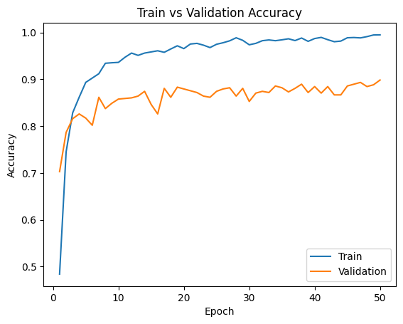

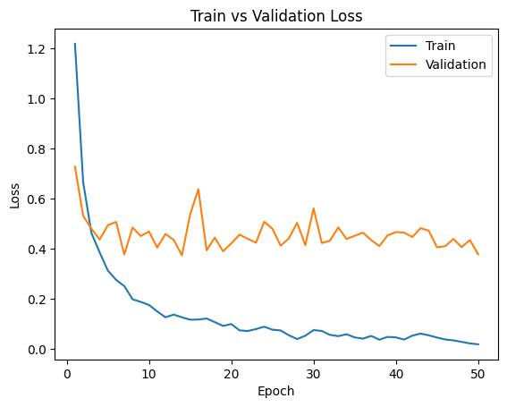

```python
net = CNN(num_classes=5)
train(net, train_dataset, val_dataset, batch_size=32, learning_rate=0.0005, num_epochs=50, use_cuda=True)
```

```
Using device: cuda
Epoch 1: Train Acc: 0.3968, Train Loss: 1.4087 | Validation Acc: 0.4473, Validation Loss: 1.3863
Epoch 2: Train Acc: 0.6551, Train Loss: 0.8957 | Validation Acc: 0.7382, Validation Loss: 0.6748
Epoch 3: Train Acc: 0.7967, Train Loss: 0.5661 | Validation Acc: 0.7980, Validation Loss: 0.5344
Epoch 4: Train Acc: 0.8587, Train Loss: 0.4144 | Validation Acc: 0.8043, Validation Loss: 0.5359
Epoch 5: Train Acc: 0.9047, Train Loss: 0.2875 | Validation Acc: 0.8018, Validation Loss: 0.5044
Epoch 6: Train Acc: 0.9273, Train Loss: 0.2233 | Validation Acc: 0.8183, Validation Loss: 0.4873
Epoch 7: Train Acc: 0.9352, Train Loss: 0.1989 | Validation Acc: 0.8272, Validation Loss: 0.4822
Epoch 8: Train Acc: 0.9513, Train Loss: 0.1653 | Validation Acc: 0.8361, Validation Loss: 0.4726
Epoch 9: Train Acc: 0.9543, Train Loss: 0.1420 | Validation Acc: 0.8475, Validation Loss: 0.4856
Epoch 10: Train Acc: 0.9605, Train Loss: 0.1215 | Validation Acc: 0.8590, Validation Loss: 0.4253
Epoch 11: Train Acc: 0.9690, Train Loss: 0.0985 | Validation Acc: 0.8488, Validation Loss: 0.5462
Epoch 12: Train Acc: 0.9690, Train Loss: 0.0962 | Validation Acc: 0.8501, Validation Loss: 0.4475
Epoch 13: Train Acc: 0.9788, Train Loss: 0.0749 | Validation Acc: 0.8577, Validation Loss: 0.5016
Epoch 14: Train Acc: 0.9706, Train Loss: 0.0825 | Validation Acc: 0.8590, Validation Loss: 0.4592
Epoch 15: Train Acc: 0.9752, Train Loss: 0.0753 | Validation Acc: 0.8539, Validation Loss: 0.4806
Epoch 16: Train Acc: 0.9809, Train Loss: 0.0670 | Validation Acc: 0.8399, Validation Loss: 0.5459
Epoch 17: Train Acc: 0.9790, Train Loss: 0.0699 | Validation Acc: 0.8577, Validation Loss: 0.4970
Epoch 18: Train Acc: 0.9752, Train Loss: 0.0810 | Validation Acc: 0.8564, Validation Loss: 0.4562
Epoch 19: Train Acc: 0.9845, Train Loss: 0.0567 | Validation Acc: 0.8526, Validation Loss: 0.5034
Epoch 20: Train Acc: 0.9771, Train Loss: 0.0688 | Validation Acc: 0.8450, Validation Loss: 0.4968
Epoch 21: Train Acc: 0.9829, Train Loss: 0.0564 | Validation Acc: 0.8513, Validation Loss: 0.5415
Epoch 22: Train Acc: 0.9853, Train Loss: 0.0526 | Validation Acc: 0.8437, Validation Loss: 0.5844
Epoch 23: Train Acc: 0.9758, Train Loss: 0.0855 | Validation Acc: 0.8577, Validation Loss: 0.5170
Epoch 24: Train Acc: 0.9845, Train Loss: 0.0534 | Validation Acc: 0.8590, Validation Loss: 0.4630
Epoch 25: Train Acc: 0.9856, Train Loss: 0.0456 | Validation Acc: 0.8526, Validation Loss: 0.5572
Epoch 26: Train Acc: 0.9886, Train Loss: 0.0382 | Validation Acc: 0.8513, Validation Loss: 0.5986
Epoch 27: Train Acc: 0.9907, Train Loss: 0.0360 | Validation Acc: 0.8780, Validation Loss: 0.4419
Epoch 28: Train Acc: 0.9916, Train Loss: 0.0302 | Validation Acc: 0.8590, Validation Loss: 0.5706
Epoch 29: Train Acc: 0.9883, Train Loss: 0.0427 | Validation Acc: 0.8666, Validation Loss: 0.4992
Epoch 30: Train Acc: 0.9907, Train Loss: 0.0324 | Validation Acc: 0.8679, Validation Loss: 0.4660
Epoch 31: Train Acc: 0.9907, Train Loss: 0.0309 | Validation Acc: 0.8424, Validation Loss: 0.5847
Epoch 32: Train Acc: 0.9845, Train Loss: 0.0401 | Validation Acc: 0.8615, Validation Loss: 0.6155
Epoch 33: Train Acc: 0.9875, Train Loss: 0.0368 | Validation Acc: 0.8590, Validation Loss: 0.5346
Epoch 34: Train Acc: 0.9878, Train Loss: 0.0441 | Validation Acc: 0.8653, Validation Loss: 0.5429
Epoch 35: Train Acc: 0.9839, Train Loss: 0.0528 | Validation Acc: 0.8628, Validation Loss: 0.5689
Epoch 36: Train Acc: 0.9899, Train Loss: 0.0303 | Validation Acc: 0.8564, Validation Loss: 0.5352
Epoch 37: Train Acc: 0.9910, Train Loss: 0.0269 | Validation Acc: 0.8755, Validation Loss: 0.5505
Epoch 38: Train Acc: 0.9924, Train Loss: 0.0308 | Validation Acc: 0.8793, Validation Loss: 0.4832
Epoch 39: Train Acc: 0.9924, Train Loss: 0.0273 | Validation Acc: 0.8653, Validation Loss: 0.5304
Epoch 40: Train Acc: 0.9943, Train Loss: 0.0256 | Validation Acc: 0.8793, Validation Loss: 0.4415
Epoch 41: Train Acc: 0.9940, Train Loss: 0.0193 | Validation Acc: 0.8577, Validation Loss: 0.5939
Epoch 42: Train Acc: 0.9916, Train Loss: 0.0342 | Validation Acc: 0.8755, Validation Loss: 0.4657
Epoch 43: Train Acc: 0.9940, Train Loss: 0.0211 | Validation Acc: 0.8590, Validation Loss: 0.5683
Epoch 44: Train Acc: 0.9937, Train Loss: 0.0208 | Validation Acc: 0.8755, Validation Loss: 0.4910
Epoch 45: Train Acc: 0.9891, Train Loss: 0.0376 | Validation Acc: 0.8551, Validation Loss: 0.5038
Epoch 46: Train Acc: 0.9927, Train Loss: 0.0246 | Validation Acc: 0.8742, Validation Loss: 0.4758
Epoch 47: Train Acc: 0.9935, Train Loss: 0.0208 | Validation Acc: 0.8602, Validation Loss: 0.5718
Epoch 48: Train Acc: 0.9927, Train Loss: 0.0227 | Validation Acc: 0.8666, Validation Loss: 0.4754
Epoch 49: Train Acc: 0.9948, Train Loss: 0.0173 | Validation Acc: 0.8640, Validation Loss: 0.5090
Epoch 50: Train Acc: 0.9946, Train Loss: 0.0188 | Validation Acc: 0.8717, Validation Loss: 0.4803
Training complete
Total time: 17.51 秒
```

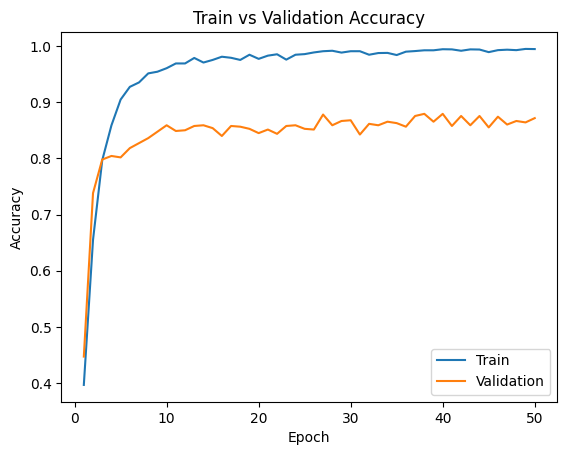

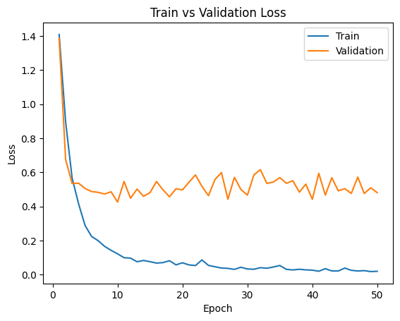

```python
net = CNN(num_classes=5)
train(net, train_dataset, val_dataset, batch_size=64, learning_rate=0.0005, num_epochs=50, use_cuda=True)
```

```
Using device: cuda
Epoch 1: Train Acc: 0.4502, Train Loss: 1.2796 | Validation Acc: 0.6582, Validation Loss: 1.0549
Epoch 2: Train Acc: 0.7194, Train Loss: 0.7068 | Validation Acc: 0.7878, Validation Loss: 0.5539
Epoch 3: Train Acc: 0.8304, Train Loss: 0.4521 | Validation Acc: 0.7840, Validation Loss: 0.5500
Epoch 4: Train Acc: 0.8821, Train Loss: 0.3392 | Validation Acc: 0.8158, Validation Loss: 0.4757
Epoch 5: Train Acc: 0.9194, Train Loss: 0.2417 | Validation Acc: 0.7992, Validation Loss: 0.6055
Epoch 6: Train Acc: 0.9077, Train Loss: 0.2442 | Validation Acc: 0.8361, Validation Loss: 0.4317
Epoch 7: Train Acc: 0.9320, Train Loss: 0.2031 | Validation Acc: 0.8285, Validation Loss: 0.4826
Epoch 8: Train Acc: 0.9472, Train Loss: 0.1585 | Validation Acc: 0.8488, Validation Loss: 0.4334
Epoch 9: Train Acc: 0.9434, Train Loss: 0.1617 | Validation Acc: 0.8374, Validation Loss: 0.5058
Epoch 10: Train Acc: 0.9630, Train Loss: 0.1212 | Validation Acc: 0.8717, Validation Loss: 0.4171
Epoch 11: Train Acc: 0.9682, Train Loss: 0.0965 | Validation Acc: 0.8539, Validation Loss: 0.4643
Epoch 12: Train Acc: 0.9676, Train Loss: 0.0999 | Validation Acc: 0.8679, Validation Loss: 0.4353
Epoch 13: Train Acc: 0.9750, Train Loss: 0.0794 | Validation Acc: 0.7942, Validation Loss: 0.8170
Epoch 14: Train Acc: 0.9725, Train Loss: 0.0834 | Validation Acc: 0.8679, Validation Loss: 0.4214
Epoch 15: Train Acc: 0.9766, Train Loss: 0.0686 | Validation Acc: 0.8463, Validation Loss: 0.5324
Epoch 16: Train Acc: 0.9766, Train Loss: 0.0735 | Validation Acc: 0.8437, Validation Loss: 0.5971
Epoch 17: Train Acc: 0.9741, Train Loss: 0.0714 | Validation Acc: 0.8412, Validation Loss: 0.5941
Epoch 18: Train Acc: 0.9638, Train Loss: 0.1079 | Validation Acc: 0.8666, Validation Loss: 0.4469
Epoch 19: Train Acc: 0.9771, Train Loss: 0.0722 | Validation Acc: 0.8539, Validation Loss: 0.5530
Epoch 20: Train Acc: 0.9809, Train Loss: 0.0561 | Validation Acc: 0.8475, Validation Loss: 0.5531
Epoch 21: Train Acc: 0.9858, Train Loss: 0.0449 | Validation Acc: 0.8501, Validation Loss: 0.5951
Epoch 22: Train Acc: 0.9782, Train Loss: 0.0694 | Validation Acc: 0.8653, Validation Loss: 0.4993
Epoch 23: Train Acc: 0.9831, Train Loss: 0.0502 | Validation Acc: 0.8691, Validation Loss: 0.5255
Epoch 24: Train Acc: 0.9823, Train Loss: 0.0569 | Validation Acc: 0.8653, Validation Loss: 0.4512
Epoch 25: Train Acc: 0.9880, Train Loss: 0.0354 | Validation Acc: 0.8793, Validation Loss: 0.4743
Epoch 26: Train Acc: 0.9891, Train Loss: 0.0319 | Validation Acc: 0.8564, Validation Loss: 0.5588
Epoch 27: Train Acc: 0.9894, Train Loss: 0.0356 | Validation Acc: 0.8729, Validation Loss: 0.4971
Epoch 28: Train Acc: 0.9946, Train Loss: 0.0197 | Validation Acc: 0.8767, Validation Loss: 0.4898
Epoch 29: Train Acc: 0.9902, Train Loss: 0.0305 | Validation Acc: 0.8679, Validation Loss: 0.4983
Epoch 30: Train Acc: 0.9886, Train Loss: 0.0344 | Validation Acc: 0.8831, Validation Loss: 0.4700
Epoch 31: Train Acc: 0.9850, Train Loss: 0.0459 | Validation Acc: 0.8640, Validation Loss: 0.5812
Epoch 32: Train Acc: 0.9913, Train Loss: 0.0330 | Validation Acc: 0.8285, Validation Loss: 0.8545
Epoch 33: Train Acc: 0.9924, Train Loss: 0.0274 | Validation Acc: 0.8539, Validation Loss: 0.6787
Epoch 34: Train Acc: 0.9910, Train Loss: 0.0305 | Validation Acc: 0.8742, Validation Loss: 0.5550
Epoch 35: Train Acc: 0.9750, Train Loss: 0.0740 | Validation Acc: 0.8615, Validation Loss: 0.5537
Epoch 36: Train Acc: 0.9894, Train Loss: 0.0351 | Validation Acc: 0.8742, Validation Loss: 0.4820
Epoch 37: Train Acc: 0.9902, Train Loss: 0.0358 | Validation Acc: 0.8640, Validation Loss: 0.5684
Epoch 38: Train Acc: 0.9897, Train Loss: 0.0315 | Validation Acc: 0.8742, Validation Loss: 0.4896
Epoch 39: Train Acc: 0.9853, Train Loss: 0.0394 | Validation Acc: 0.8679, Validation Loss: 0.4864
Epoch 40: Train Acc: 0.9897, Train Loss: 0.0310 | Validation Acc: 0.8539, Validation Loss: 0.5569
Epoch 41: Train Acc: 0.9924, Train Loss: 0.0234 | Validation Acc: 0.8628, Validation Loss: 0.5977
Epoch 42: Train Acc: 0.9918, Train Loss: 0.0259 | Validation Acc: 0.8640, Validation Loss: 0.5812
Epoch 43: Train Acc: 0.9883, Train Loss: 0.0312 | Validation Acc: 0.8628, Validation Loss: 0.5693
Epoch 44: Train Acc: 0.9910, Train Loss: 0.0322 | Validation Acc: 0.8780, Validation Loss: 0.5176
Epoch 45: Train Acc: 0.9910, Train Loss: 0.0260 | Validation Acc: 0.8767, Validation Loss: 0.4857
Epoch 46: Train Acc: 0.9894, Train Loss: 0.0352 | Validation Acc: 0.8818, Validation Loss: 0.5079
Epoch 47: Train Acc: 0.9940, Train Loss: 0.0229 | Validation Acc: 0.8895, Validation Loss: 0.4532
Epoch 48: Train Acc: 0.9948, Train Loss: 0.0135 | Validation Acc: 0.8831, Validation Loss: 0.4738
Epoch 49: Train Acc: 0.9940, Train Loss: 0.0193 | Validation Acc: 0.8780, Validation Loss: 0.5318
Epoch 50: Train Acc: 0.9935, Train Loss: 0.0248 | Validation Acc: 0.8831, Validation Loss: 0.4698
Training complete
Total time: 17.34 秒
```

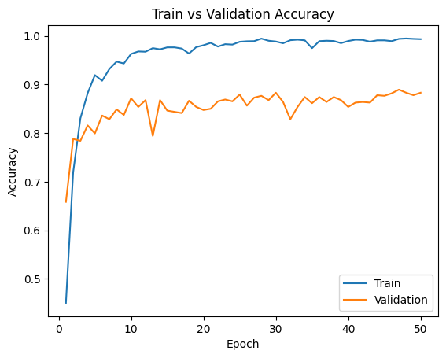

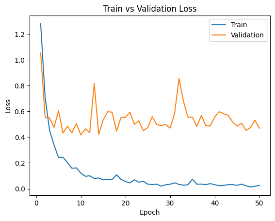

```python
net = CNN(num_classes=5)
train(net, train_dataset, val_dataset, batch_size=64, learning_rate=0.001, num_epochs=50, use_cuda=True)
```

Our current implementation establishes a voice-driven mood classification system using Wav2Vec2 for feature extraction and a CNN-based classifier. While the core functionality is in place, we recognize opportunities for further improvement. One major enhancement will be the integration of a recommendation system via an API. This system will utilize the classified emotion labels to generate personalized entertainment suggestions, such as music or movies, tailored to the user's mood. The API will be responsible for dynamically creating prompts based on the detected emotions and fetching relevant content. Additionally, we plan to enhance model performance by incorporating a larger and more diverse dataset, which will improve generalization across different speech variations and emotional tones. Further optimizations in model training, such as hyperparameter tuning, additional data augmentation techniques, and experimenting with different architectures, may also be explored. Finally, we aim to deploy the system as a web application, allowing users to interact with it in real-time, providing an intuitive and accessible interface for mood detection and entertainment recommendations.

## Incorporating with whole dataset (After Midterm Progress)

To enhance the performance and generalization ability of our model, we expanded the training data by incorporating the entire Emotional Speech Dataset (ESD). Initially, we only used data from three speakers for model prototyping and debugging. After the midterm checkpoint, we transitioned to the full dataset, which includes 35,000 audio samples spanning five emotion categories: Neutral, Happy, Angry, Sad, and Surprise. This allowed our model to learn from a more diverse and comprehensive set of speech variations, improving robustness and reliability on unseen data.

```python
data_path = "/content/drive/MyDrive/MIE1517 project/Emotional Speech Dataset (ESD)/Emotion Speech Dataset"

#Using 3 people as our initial training
dataset = ESDDataset(data_path, feature_extractor)

print(f"Length of dataset: {len(dataset)}")
```

```
Find 35000 audio samples.
Length of dataset: 35000
```

After loading the full dataset, we split it into training, validation, and testing sets using a 70/15/15 ratio. Specifically, out of the 35,000 audio samples, 24,500 were used for training, 5,250 for validation, and 5,250 for testing.

We then created PyTorch DataLoader objects for each subset to facilitate batch-wise data loading. A custom collate_fn function was used to ensure the input tensors are properly aligned and padded, making the data compatible with the Wav2Vec2 model. The training loader uses shuffling to introduce variability and improve generalization, while validation and testing loaders are kept in order for consistent evaluation.

```python
#Set the data set path
data_path = "/content/drive/MyDrive/MIE1517 project/Emotional Speech Dataset (ESD)/Emotion Speech Dataset"
dataset = ESDDataset(data_path, feature_extractor)

#Divide the data set (70% training, 15% validation, 15% testing)
train_size = int(0.7 * len(dataset))
val_size = int(0.15 * len(dataset))
test_size = len(dataset) - train_size - val_size

train_dataset, val_dataset, test_dataset = random_split(dataset, [train_size, val_size, test_size])

#Set DataLoader
train_loader = DataLoader(train_dataset, batch_size=1, shuffle=True, collate_fn=collate_fn)
val_loader = DataLoader(val_dataset, batch_size=1, shuffle=False, collate_fn=collate_fn)
test_loader = DataLoader(test_dataset, batch_size=1, shuffle=False, collate_fn=collate_fn)

print(f"Training set size: {len(train_dataset)}")
print(f"Validation set size: {len(val_dataset)}")
print(f"Testing set size: {len(test_dataset)}")
```

```
Find 35000 audio samples.
Training set size: 24500
Validation set size: 5250
Testing set size: 5250
```

```python
batch = next(iter(train_loader))

print(f"Batch input_values shape: {batch['input_values'].shape}")  # (batch_size, max_seq_length)
print(f"Batch labels shape: {batch['labels'].shape}")  # (batch_size,)
print(f"Batch input_values dtype: {batch['input_values'].dtype}")  # torch.float32
print(f"Batch labels dtype: {batch['labels'].dtype}")  # torch.int64
```

```
Batch input_values shape: torch.Size([1, 65120])
Batch labels shape: torch.Size([1])
Batch input_values dtype: torch.float32
Batch labels dtype: torch.int64
```

After preparing the data loaders, we performed feature extraction using the pretrained Wav2Vec2-base model. Each audio sample was converted into a 768-dimensional feature vector representing high-level acoustic characteristics. This process involved:

- Sending each batch of audio through the Wav2Vec2 model.
- Extracting the hidden states from the last layer.
- Applying mean pooling along the time axis to reduce variable-length outputs into fixed-size vectors.

```python
def compute_features(dataloader, model, feature_extractor, device):
    model.to(device)
    features = []
    labels = []

    with torch.no_grad():
        for batch in dataloader:
            audio = batch["input_values"].to(device)
            target = batch["labels"].to(device)

            #Extract features
            inputs = feature_extractor(audio, sampling_rate=16000, return_tensors="pt", padding=True)
            inputs = {k: v.to(device) for k, v in inputs.items()}
            inputs["input_values"] = inputs["input_values"].squeeze(0)

            #Get Hidden States
            outputs = model(**inputs)
            hidden_states = outputs.last_hidden_state  #(batch, time_steps, 768)

            #Use average pooling to keep the dimensions fixed
            hidden_states = hidden_states.mean(dim=1)  #Get (batch, 768)

            features.append(hidden_states)
            labels.append(target)

    features = torch.cat(features, dim=0)
    labels = torch.cat(labels, dim=0)

    return features, labels

torch.manual_seed(1000)
device = torch.device("cuda" if torch.cuda.is_available() else "cpu")

train_features, train_labels = compute_features(train_loader, model, feature_extractor, device)
val_features, val_labels = compute_features(val_loader, model, feature_extractor, device)
test_features, test_labels = compute_features(test_loader, model, feature_extractor, device)

train_dataset = TensorDataset(train_features, train_labels)
val_dataset = TensorDataset(val_features, val_labels)
test_dataset = TensorDataset(test_features, test_labels)


print("Train Features Shape:", train_features.shape)
print("Validation Features Shape:", val_features.shape)
print("Test Features Shape:", test_features.shape)
```

```
Find 35000 audio samples.
Training set size: 24500
Validation set size: 5250
Testing set size: 5250
Train Features Shape: torch.Size([24500, 768])
Validation Features Shape: torch.Size([5250, 768])
Test Features Shape: torch.Size([5250, 768])
```

## ⚡The code step above took approximately 5h more with T4 GPU on google colab

**Model Architecture & Training Process:**

We implemented a 1D Convolutional Neural Network (CNN) to classify emotional states from 768-dimensional Wav2Vec2 features. The network consists of three convolutional blocks, each followed by batch normalization, ReLU activation, and adaptive max pooling to reduce feature dimensions. A fully connected layer maps the extracted features to one of five emotion classes, with dropout applied for regularization.

**Training Strategy:**

The model was trained using:

- CrossEntropyLoss as the objective function
- Stochastic Gradient Descent (SGD) with momentum for optimization
- Training was done for a configurable number of epochs, with accuracy and loss tracked at each epoch

To monitor generalization, training and validation accuracy/loss curves were generated using matplotlib. The model checkpoint was saved at the end of each epoch.

```python
class CNN(nn.Module):
    def __init__(self, num_classes):
        super(CNN, self).__init__()
        self.name = "CNN"

        self.conv1 = nn.Conv1d(in_channels=768, out_channels=256, kernel_size=3, padding=1)
        self.bn1 = nn.BatchNorm1d(256)
        self.pool = nn.AdaptiveMaxPool1d(output_size=96)

        self.conv2 = nn.Conv1d(in_channels=256, out_channels=128, kernel_size=3, padding=1)
        self.bn2 = nn.BatchNorm1d(128)

        self.conv3 = nn.Conv1d(in_channels=128, out_channels=64, kernel_size=3, padding=1)
        self.bn3 = nn.BatchNorm1d(64)

        self.fc1 = nn.Linear(64 * 96, 128)
        self.dropout = nn.Dropout(0.5)
        self.fc2 = nn.Linear(128, num_classes)

    def forward(self, x):
        x = x.unsqueeze(1)
        x = x.permute(0, 2, 1)

        x = F.relu(self.bn1(self.conv1(x)))
        #print(f"Before pooling 1, x shape: {x.shape}")
        x = self.pool(x)
        #print(f"After pooling 1, x shape: {x.shape}")

        x = F.relu(self.bn2(self.conv2(x)))
        #print(f"Before pooling 2, x shape: {x.shape}")
        x = self.pool(x)
        #print(f"After pooling 2, x shape: {x.shape}")

        x = F.relu(self.bn3(self.conv3(x)))
        #print(f"Before pooling 3, x shape: {x.shape}")
        x = self.pool(x)
        #print(f"After pooling 3, x shape: {x.shape}")

        x = x.view(x.size(0), -1)
        x = F.relu(self.fc1(x))
        x = self.dropout(x)
        x = self.fc2(x)

        return x


#Evaluation function (calculate accuracy)
def evaluatecnn(model, data_loader, criterion, device):
    model.eval()
    total_loss = 0.0
    correct = 0
    total_samples = 0

    with torch.no_grad():
        for inputs, labels in data_loader:
            inputs, labels = inputs.to(device), labels.to(device)
            outputs = model(inputs)
            loss = criterion(outputs, labels)
            total_loss += loss.item()

            _, predicted = torch.max(outputs, 1)
            correct += (predicted == labels).sum().item()
            total_samples += len(labels)

    accuracy = correct / total_samples  #Calculate accuracy
    return accuracy, total_loss / len(data_loader)


#Training function
def train(net, train_dataset, val_dataset, batch_size=32, learning_rate=0.01, num_epochs=5, use_cuda=True):
    torch.manual_seed(1000)
    device = torch.device("cuda" if use_cuda and torch.cuda.is_available() else "cpu")
    print(f"Using device: {device}")
    net.to(device)

    #DataLoader
    train_loader = DataLoader(train_dataset, batch_size=batch_size, shuffle=True)
    val_loader = DataLoader(val_dataset, batch_size=batch_size, shuffle=False)

    #Cross entropy loss
    criterion = nn.CrossEntropyLoss().to(device)
    optimizer = optim.SGD(net.parameters(), lr=learning_rate, momentum=0.9)

    train_acc = np.zeros(num_epochs)  #Replace train_err
    train_loss = np.zeros(num_epochs)
    val_acc = np.zeros(num_epochs)  #Replace val_err
    val_loss = np.zeros(num_epochs)
    start_time = time.time()

    for epoch in range(num_epochs):
        total_train_loss = 0.0
        correct = 0  #Record the correct number of samples for training

        total_samples = 0

        net.train()
        for i, (inputs, labels) in enumerate(train_loader):
            inputs, labels = inputs.to(device), labels.to(device)
            optimizer.zero_grad()

            #forward propagation
            outputs = net(inputs)
            loss = criterion(outputs, labels)
            loss.backward()
            optimizer.step()

            _, predicted = torch.max(outputs, 1)
            correct += (predicted == labels).sum().item()
            total_train_loss += loss.item()
            total_samples += len(labels)

        #Calculate Train Accuracy
        train_acc[epoch] = correct / total_samples
        train_loss[epoch] = float(total_train_loss) / (i + 1)

        #Calcualte Validation Accuracy
        val_acc[epoch], val_loss[epoch] = evaluatecnn(net, val_loader, criterion, device)

        print(f"Epoch {epoch + 1}: Train Acc: {train_acc[epoch]:.4f}, Train Loss: {train_loss[epoch]:.4f} | "
              f"Validation Acc: {val_acc[epoch]:.4f}, Validation Loss: {val_loss[epoch]:.4f}")

        #Save model
        model_path = f"model_{net.name}_bs{batch_size}_lr{learning_rate}_epoch{epoch}"
        torch.save(net.state_dict(), model_path + ".pt")

    print("Training complete")
    end_time = time.time()
    print(f"Total time: {end_time - start_time:.2f} 秒")

    #Save training results
    np.savetxt(f"{model_path}_train_acc.csv", train_acc)  #Save Accuracy
    np.savetxt(f"{model_path}_train_loss.csv", train_loss)
    np.savetxt(f"{model_path}_val_acc.csv", val_acc)
    np.savetxt(f"{model_path}_val_loss.csv", val_loss)

    plot_training_curve(model_path)


#Plot accuracy curve
def plot_training_curve(model_path):
    train_acc = np.loadtxt(f"{model_path}_train_acc.csv")
    val_acc = np.loadtxt(f"{model_path}_val_acc.csv")
    train_loss = np.loadtxt(f"{model_path}_train_loss.csv")
    val_loss = np.loadtxt(f"{model_path}_val_loss.csv")

    plt.figure()
    plt.title("Train vs Validation Accuracy")
    plt.plot(range(1, len(train_acc) + 1), train_acc, label="Train")
    plt.plot(range(1, len(val_acc) + 1), val_acc, label="Validation")
    plt.xlabel("Epoch")
    plt.ylabel("Accuracy")
    plt.legend(loc='best')
    plt.show()

    plt.figure()
    plt.title("Train vs Validation Loss")
    plt.plot(range(1, len(train_loss) + 1), train_loss, label="Train")
    plt.plot(range(1, len(val_loss) + 1), val_loss, label="Validation")
    plt.xlabel("Epoch")
    plt.ylabel("Loss")
    plt.legend(loc='best')
    plt.show()
```

**Hyperparameter Tuning & Model Selection:**

To determine the optimal training configuration, we trained our CNN model under four different hyperparameter combinations. We varied batch size (bs), learning rate (lr), and number of epochs:

- Model 1: bs=32, lr=0.0005, epochs=10
- Model 2: bs=32, lr=0.0005, epochs=15
- Model 3: bs=32, lr=0.001, epochs=15
- Model 4: bs=64, lr=0.001, epochs=15

Each model was trained using the same training and validation sets, and checkpoints were saved at the end of each epoch.

```
Using device: cuda
Epoch 1: Train Acc: 0.6891, Train Loss: 0.7772 | Validation Acc: 0.7771, Validation Loss: 0.5708
Best model updated: best_model_CNN_bs32_lr0.0005_epoch1_acc0.7771.pth
Epoch 2: Train Acc: 0.8297, Train Loss: 0.4567 | Validation Acc: 0.8690, Validation Loss: 0.3468
Best model updated: best_model_CNN_bs32_lr0.0005_epoch2_acc0.8690.pth
Epoch 3: Train Acc: 0.8675, Train Loss: 0.3534 | Validation Acc: 0.8872, Validation Loss: 0.2957
Best model updated: best_model_CNN_bs32_lr0.0005_epoch3_acc0.8872.pth
Epoch 4: Train Acc: 0.8845, Train Loss: 0.3085 | Validation Acc: 0.8924, Validation Loss: 0.2867
Best model updated: best_model_CNN_bs32_lr0.0005_epoch4_acc0.8924.pth
Epoch 5: Train Acc: 0.9039, Train Loss: 0.2674 | Validation Acc: 0.9114, Validation Loss: 0.2562
Best model updated: best_model_CNN_bs32_lr0.0005_epoch5_acc0.9114.pth
Epoch 6: Train Acc: 0.9132, Train Loss: 0.2342 | Validation Acc: 0.8958, Validation Loss: 0.2869
Epoch 7: Train Acc: 0.9210, Train Loss: 0.2160 | Validation Acc: 0.9074, Validation Loss: 0.2454
Epoch 8: Train Acc: 0.9280, Train Loss: 0.2009 | Validation Acc: 0.9107, Validation Loss: 0.2565
Epoch 9: Train Acc: 0.9356, Train Loss: 0.1821 | Validation Acc: 0.9238, Validation Loss: 0.2161
Best model updated: best_model_CNN_bs32_lr0.0005_epoch9_acc0.9238.pth
Epoch 10: Train Acc: 0.9351, Train Loss: 0.1759 | Validation Acc: 0.9088, Validation Loss: 0.2461
Training complete
Total training time: 36.74 seconds
```

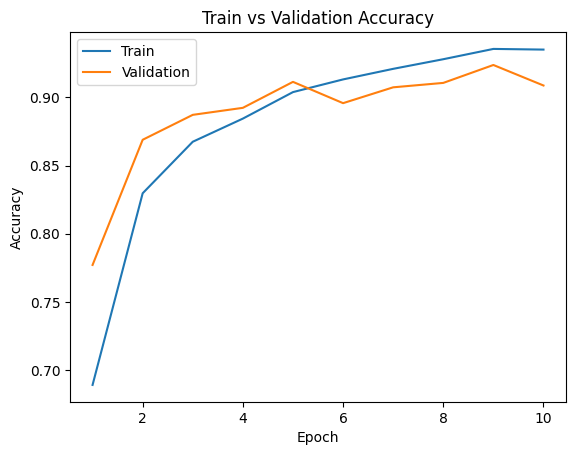

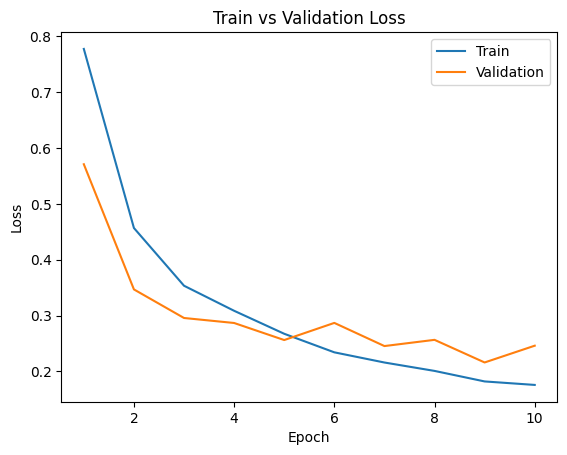

```python
net_full = CNN(num_classes=5)
train(net_full, train_dataset, val_dataset, batch_size=32, learning_rate=0.0005, num_epochs=10, use_cuda=True)
```

```
Using device: cuda
Epoch 1: Train Acc: 0.6871, Train Loss: 0.7781 | Validation Acc: 0.7899, Validation Loss: 0.5309
Best model updated: best_model_CNN_bs32_lr0.0005_epoch1_acc0.7899.pth
Epoch 2: Train Acc: 0.8290, Train Loss: 0.4588 | Validation Acc: 0.8634, Validation Loss: 0.3582
Best model updated: best_model_CNN_bs32_lr0.0005_epoch2_acc0.8634.pth
Epoch 3: Train Acc: 0.8653, Train Loss: 0.3597 | Validation Acc: 0.8838, Validation Loss: 0.3135
Best model updated: best_model_CNN_bs32_lr0.0005_epoch3_acc0.8838.pth
Epoch 4: Train Acc: 0.8863, Train Loss: 0.3067 | Validation Acc: 0.8954, Validation Loss: 0.2848
Best model updated: best_model_CNN_bs32_lr0.0005_epoch4_acc0.8954.pth
Epoch 5: Train Acc: 0.9005, Train Loss: 0.2742 | Validation Acc: 0.9004, Validation Loss: 0.2760
Best model updated: best_model_CNN_bs32_lr0.0005_epoch5_acc0.9004.pth
Epoch 6: Train Acc: 0.9116, Train Loss: 0.2403 | Validation Acc: 0.8886, Validation Loss: 0.3223
Epoch 7: Train Acc: 0.9209, Train Loss: 0.2182 | Validation Acc: 0.9080, Validation Loss: 0.2603
Best model updated: best_model_CNN_bs32_lr0.0005_epoch7_acc0.9080.pth
Epoch 8: Train Acc: 0.9276, Train Loss: 0.2007 | Validation Acc: 0.9114, Validation Loss: 0.2470
Best model updated: best_model_CNN_bs32_lr0.0005_epoch8_acc0.9114.pth
Epoch 9: Train Acc: 0.9354, Train Loss: 0.1820 | Validation Acc: 0.9217, Validation Loss: 0.2324
Best model updated: best_model_CNN_bs32_lr0.0005_epoch9_acc0.9217.pth
Epoch 10: Train Acc: 0.9381, Train Loss: 0.1733 | Validation Acc: 0.8998, Validation Loss: 0.2875
Epoch 11: Train Acc: 0.9416, Train Loss: 0.1606 | Validation Acc: 0.8943, Validation Loss: 0.3123
Epoch 12: Train Acc: 0.9477, Train Loss: 0.1465 | Validation Acc: 0.9248, Validation Loss: 0.2409
Best model updated: best_model_CNN_bs32_lr0.0005_epoch12_acc0.9248.pth
Epoch 13: Train Acc: 0.9504, Train Loss: 0.1384 | Validation Acc: 0.9156, Validation Loss: 0.2461
Epoch 14: Train Acc: 0.9518, Train Loss: 0.1359 | Validation Acc: 0.9206, Validation Loss: 0.2413
Epoch 15: Train Acc: 0.9543, Train Loss: 0.1268 | Validation Acc: 0.9154, Validation Loss: 0.2612
Training complete
Total training time: 55.56 seconds
```

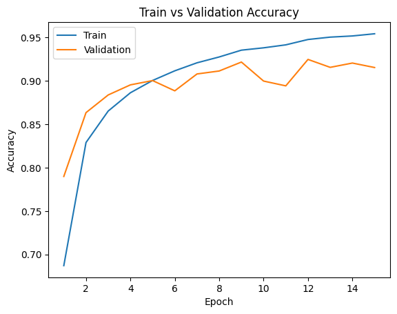

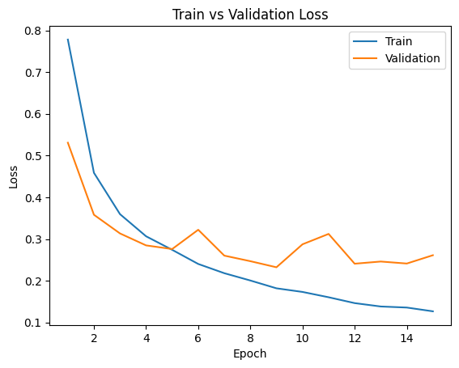

```python
net_full = CNN(num_classes=5)
train(net_full, train_dataset, val_dataset, batch_size=32, learning_rate=0.0005, num_epochs=15, use_cuda=True)
```

```
Using device: cuda
Epoch 1: Train Acc: 0.7089, Train Loss: 0.7292 | Validation Acc: 0.7964, Validation Loss: 0.5291
Best model updated: best_model_CNN_bs32_lr0.001_epoch1_acc0.7964.pth
Epoch 2: Train Acc: 0.8332, Train Loss: 0.4509 | Validation Acc: 0.8773, Validation Loss: 0.3362
Best model updated: best_model_CNN_bs32_lr0.001_epoch2_acc0.8773.pth
Epoch 3: Train Acc: 0.8697, Train Loss: 0.3563 | Validation Acc: 0.8867, Validation Loss: 0.3110
Best model updated: best_model_CNN_bs32_lr0.001_epoch3_acc0.8867.pth
Epoch 4: Train Acc: 0.8886, Train Loss: 0.3077 | Validation Acc: 0.8869, Validation Loss: 0.2983
Best model updated: best_model_CNN_bs32_lr0.001_epoch4_acc0.8869.pth
Epoch 5: Train Acc: 0.8992, Train Loss: 0.2760 | Validation Acc: 0.9095, Validation Loss: 0.2589
Best model updated: best_model_CNN_bs32_lr0.001_epoch5_acc0.9095.pth
Epoch 6: Train Acc: 0.9101, Train Loss: 0.2439 | Validation Acc: 0.9055, Validation Loss: 0.2790
Epoch 7: Train Acc: 0.9215, Train Loss: 0.2202 | Validation Acc: 0.9050, Validation Loss: 0.2470
Epoch 8: Train Acc: 0.9272, Train Loss: 0.2004 | Validation Acc: 0.8949, Validation Loss: 0.3203
Epoch 9: Train Acc: 0.9312, Train Loss: 0.1948 | Validation Acc: 0.9196, Validation Loss: 0.2325
Best model updated: best_model_CNN_bs32_lr0.001_epoch9_acc0.9196.pth
Epoch 10: Train Acc: 0.9370, Train Loss: 0.1781 | Validation Acc: 0.9105, Validation Loss: 0.2462
Epoch 11: Train Acc: 0.9415, Train Loss: 0.1649 | Validation Acc: 0.9177, Validation Loss: 0.2458
Epoch 12: Train Acc: 0.9470, Train Loss: 0.1457 | Validation Acc: 0.9088, Validation Loss: 0.2815
Epoch 13: Train Acc: 0.9506, Train Loss: 0.1413 | Validation Acc: 0.9198, Validation Loss: 0.2392
Best model updated: best_model_CNN_bs32_lr0.001_epoch13_acc0.9198.pth
Epoch 14: Train Acc: 0.9525, Train Loss: 0.1328 | Validation Acc: 0.9244, Validation Loss: 0.2214
Best model updated: best_model_CNN_bs32_lr0.001_epoch14_acc0.9244.pth
Epoch 15: Train Acc: 0.9532, Train Loss: 0.1328 | Validation Acc: 0.9164, Validation Loss: 0.2389
Training complete
Total training time: 54.97 seconds
```

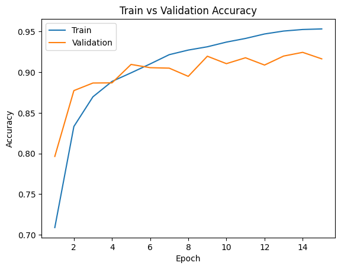

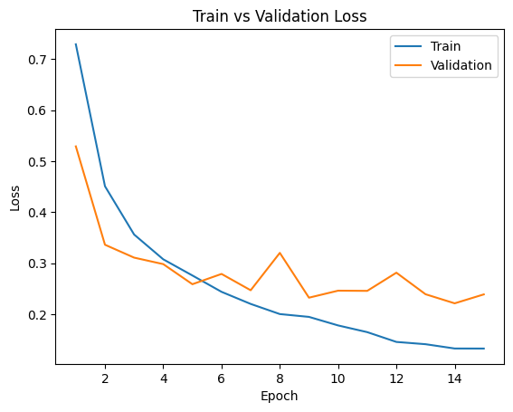

```python
net_full = CNN(num_classes=5)
train(net_full, train_dataset, val_dataset, batch_size=32, learning_rate=0.001, num_epochs=15, use_cuda=True)
```

```
Using device: cuda
Epoch 1: Train Acc: 0.6981, Train Loss: 0.7506 | Validation Acc: 0.8133, Validation Loss: 0.4886
Best model updated: best_model_CNN_bs64_lr0.001_epoch1_acc0.8133.pth
Epoch 2: Train Acc: 0.8504, Train Loss: 0.3985 | Validation Acc: 0.8518, Validation Loss: 0.3927
Best model updated: best_model_CNN_bs64_lr0.001_epoch2_acc0.8518.pth
Epoch 3: Train Acc: 0.8901, Train Loss: 0.3025 | Validation Acc: 0.8617, Validation Loss: 0.3828
Best model updated: best_model_CNN_bs64_lr0.001_epoch3_acc0.8617.pth
Epoch 4: Train Acc: 0.9047, Train Loss: 0.2613 | Validation Acc: 0.8943, Validation Loss: 0.2943
Best model updated: best_model_CNN_bs64_lr0.001_epoch4_acc0.8943.pth
Epoch 5: Train Acc: 0.9220, Train Loss: 0.2144 | Validation Acc: 0.8859, Validation Loss: 0.3243
Epoch 6: Train Acc: 0.9311, Train Loss: 0.1875 | Validation Acc: 0.8901, Validation Loss: 0.3232
Epoch 7: Train Acc: 0.9368, Train Loss: 0.1715 | Validation Acc: 0.9046, Validation Loss: 0.2696
Best model updated: best_model_CNN_bs64_lr0.001_epoch7_acc0.9046.pth
Epoch 8: Train Acc: 0.9473, Train Loss: 0.1457 | Validation Acc: 0.9088, Validation Loss: 0.2714
Best model updated: best_model_CNN_bs64_lr0.001_epoch8_acc0.9088.pth
Epoch 9: Train Acc: 0.9512, Train Loss: 0.1364 | Validation Acc: 0.9072, Validation Loss: 0.2819
Epoch 10: Train Acc: 0.9565, Train Loss: 0.1233 | Validation Acc: 0.9093, Validation Loss: 0.2771
Best model updated: best_model_CNN_bs64_lr0.001_epoch10_acc0.9093.pth
Epoch 11: Train Acc: 0.9611, Train Loss: 0.1094 | Validation Acc: 0.8983, Validation Loss: 0.3285
Epoch 12: Train Acc: 0.9624, Train Loss: 0.1058 | Validation Acc: 0.9185, Validation Loss: 0.2666
Best model updated: best_model_CNN_bs64_lr0.001_epoch12_acc0.9185.pth
Epoch 13: Train Acc: 0.9665, Train Loss: 0.0945 | Validation Acc: 0.9217, Validation Loss: 0.2394
Best model updated: best_model_CNN_bs64_lr0.001_epoch13_acc0.9217.pth
Epoch 14: Train Acc: 0.9678, Train Loss: 0.0901 | Validation Acc: 0.9078, Validation Loss: 0.2945
Epoch 15: Train Acc: 0.9686, Train Loss: 0.0874 | Validation Acc: 0.9234, Validation Loss: 0.2423
Best model updated: best_model_CNN_bs64_lr0.001_epoch15_acc0.9234.pth
Training complete
Total training time: 33.85 seconds
```

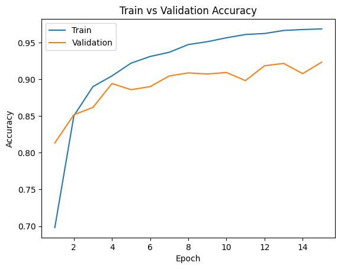

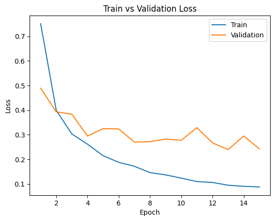

```python
net_full = CNN(num_classes=5)
train(net_full, train_dataset, val_dataset, batch_size=64, learning_rate=0.001, num_epochs=15, use_cuda=True)
```

## Testing and Evaluation

```python
from tqdm import tqdm
def compute_features(dataloader, model, feature_extractor, device):
    model.to(device)
    features = []
    labels = []

    with torch.no_grad():
        for batch in tqdm(dataloader, desc="Extracting features"):
            audio = batch["input_values"].to(device)
            target = batch["labels"].to(device)

            # Extract features
            inputs = feature_extractor(audio, sampling_rate=16000, return_tensors="pt", padding=True)
            inputs = {k: v.to(device) for k, v in inputs.items()}
            inputs["input_values"] = inputs["input_values"].squeeze(0)

            # Get hidden states
            outputs = model(**inputs)
            hidden_states = outputs.last_hidden_state  # (batch, time_steps, 768)

            # Average pooling to fix dimensions
            hidden_states = hidden_states.mean(dim=1)  # (batch, 768)

            features.append(hidden_states)
            labels.append(target)

    features = torch.cat(features, dim=0)
    labels = torch.cat(labels, dim=0)

    return features, labels

data_path = "/content/drive/MyDrive/MIE1517 project/Emotional Speech Dataset (ESD)/Emotion Speech Dataset"
dataset = ESDDataset(data_path, feature_extractor)

#Divide the data set (70% training, 15% validation, 15% testing)
train_size = int(0.7 * len(dataset))
val_size = int(0.15 * len(dataset))
test_size = len(dataset) - train_size - val_size
train_dataset, val_dataset, test_dataset = random_split(dataset, [train_size, val_size, test_size])

#Set DataLoader
test_loader = DataLoader(test_dataset, batch_size=1, shuffle=False, collate_fn=collate_fn)
print(f"Testing set size: {len(test_dataset)}")



torch.manual_seed(1000)
device = torch.device("cuda" if torch.cuda.is_available() else "cpu")
test_features, test_labels = compute_features(test_loader, model, feature_extractor, device)
test_dataset = TensorDataset(test_features, test_labels)
print("Test Features Shape:", test_features.shape)
```

```
Find 35000 audio samples.
Testing set size: 5250
```

```
Test Features Shape: torch.Size([5250, 768])
```

### Model Comparison and Selection

After determining the best-performing CNN architecture through extensive tuning, we proceeded to compare multiple trained instances of this architecture. To compare the generalization ability of our models, we loaded the **four best CNN models** that were saved during hyperparameter tuning, each trained under different batch sizes, learning rates, and epoch settings. These models were evaluated under identical conditions using the prepared test set. This allowed us to compare performance across architectures and select the most reliable configuration for deployment.

To assess model performance, we used a custom evaluation function that computes both classification accuracy and average cross-entropy loss. This was applied consistently across all four trained models using the same test set to ensure fairness.

```python
device = torch.device("cuda" if torch.cuda.is_available() else "cpu")

# Load the trained model_1
model_1 = CNN(5)
model_1.load_state_dict(torch.load("/content/best_model_CNN_bs32_lr0.0005_epoch12_acc0.9248.pth", map_location=device))
model_1.to(device)
model_1.eval()
```

```
CNN(
  (conv1): Conv1d(768, 256, kernel_size=(3,), stride=(1,), padding=(1,))
  (bn1): BatchNorm1d(256, eps=1e-05, momentum=0.1, affine=True, track_running_stats=True)
  (pool): AdaptiveMaxPool1d(output_size=96)
  (conv2): Conv1d(256, 128, kernel_size=(3,), stride=(1,), padding=(1,))
  (bn2): BatchNorm1d(128, eps=1e-05, momentum=0.1, affine=True, track_running_stats=True)
  (conv3): Conv1d(128, 64, kernel_size=(3,), stride=(1,), padding=(1,))
  (bn3): BatchNorm1d(64, eps=1e-05, momentum=0.1, affine=True, track_running_stats=True)
  (fc1): Linear(in_features=6144, out_features=128, bias=True)
  (dropout): Dropout(p=0.5, inplace=False)
  (fc2): Linear(in_features=128, out_features=5, bias=True)
)
```

```python
device = torch.device("cuda" if torch.cuda.is_available() else "cpu")

# Load the trained model_2
model_2 = CNN(5)
model_2.load_state_dict(torch.load("/content/best_model_CNN_bs32_lr0.0005_epoch9_acc0.9238.pth", map_location=device))
model_2.to(device)
model_2.eval()
```

```
CNN(
  (conv1): Conv1d(768, 256, kernel_size=(3,), stride=(1,), padding=(1,))
  (bn1): BatchNorm1d(256, eps=1e-05, momentum=0.1, affine=True, track_running_stats=True)
  (pool): AdaptiveMaxPool1d(output_size=96)
  (conv2): Conv1d(256, 128, kernel_size=(3,), stride=(1,), padding=(1,))
  (bn2): BatchNorm1d(128, eps=1e-05, momentum=0.1, affine=True, track_running_stats=True)
  (conv3): Conv1d(128, 64, kernel_size=(3,), stride=(1,), padding=(1,))
  (bn3): BatchNorm1d(64, eps=1e-05, momentum=0.1, affine=True, track_running_stats=True)
  (fc1): Linear(in_features=6144, out_features=128, bias=True)
  (dropout): Dropout(p=0.5, inplace=False)
  (fc2): Linear(in_features=128, out_features=5, bias=True)
)
```

```python
device = torch.device("cuda" if torch.cuda.is_available() else "cpu")

# Load the trained model_3
model_3 = CNN(5)
model_3.load_state_dict(torch.load("/content/best_model_CNN_bs32_lr0.001_epoch14_acc0.9244.pth", map_location=device))
model_3.to(device)
model_3.eval()
```

```
CNN(
  (conv1): Conv1d(768, 256, kernel_size=(3,), stride=(1,), padding=(1,))
  (bn1): BatchNorm1d(256, eps=1e-05, momentum=0.1, affine=True, track_running_stats=True)
  (pool): AdaptiveMaxPool1d(output_size=96)
  (conv2): Conv1d(256, 128, kernel_size=(3,), stride=(1,), padding=(1,))
  (bn2): BatchNorm1d(128, eps=1e-05, momentum=0.1, affine=True, track_running_stats=True)
  (conv3): Conv1d(128, 64, kernel_size=(3,), stride=(1,), padding=(1,))
  (bn3): BatchNorm1d(64, eps=1e-05, momentum=0.1, affine=True, track_running_stats=True)
  (fc1): Linear(in_features=6144, out_features=128, bias=True)
  (dropout): Dropout(p=0.5, inplace=False)
  (fc2): Linear(in_features=128, out_features=5, bias=True)
)
```

```python
device = torch.device("cuda" if torch.cuda.is_available() else "cpu")

# Load the trained model_4
model_4 = CNN(5)
model_4.load_state_dict(torch.load("/content/best_model_CNN_bs64_lr0.001_epoch15_acc0.9234.pth", map_location=device))
model_4.to(device)
model_4.eval()
```

```
CNN(
  (conv1): Conv1d(768, 256, kernel_size=(3,), stride=(1,), padding=(1,))
  (bn1): BatchNorm1d(256, eps=1e-05, momentum=0.1, affine=True, track_running_stats=True)
  (pool): AdaptiveMaxPool1d(output_size=96)
  (conv2): Conv1d(256, 128, kernel_size=(3,), stride=(1,), padding=(1,))
  (bn2): BatchNorm1d(128, eps=1e-05, momentum=0.1, affine=True, track_running_stats=True)
  (conv3): Conv1d(128, 64, kernel_size=(3,), stride=(1,), padding=(1,))
  (bn3): BatchNorm1d(64, eps=1e-05, momentum=0.1, affine=True, track_running_stats=True)
  (fc1): Linear(in_features=6144, out_features=128, bias=True)
  (dropout): Dropout(p=0.5, inplace=False)
  (fc2): Linear(in_features=128, out_features=5, bias=True)
)
```

```python
test_loader = DataLoader(test_dataset, batch_size=32, shuffle=False)
```

```python
criterion = nn.CrossEntropyLoss().to(device)
evaluatecnn(model_1, test_loader, criterion, device)
```

```
(0.9647619047619047, 0.10507654126620654)
```